# Job-Interview

Pamela M. Chiroque-Solano

2022-06-07 11:40:36

This document was compiled on date 2022-06-07 11:40:36 by Pamela Solano for the job-interview.

# 1 Modelling Infectious Diseases: SIR model

## 1.1 Task 1

Implement the following epidemiologic SIR model (S=Susceptible, I=Infected, R=Recovered)

$$\begin{align}
\frac{dS}{dt} &= - \alpha S I \notag \\
\notag \\
\frac{dI}{dt} &= \alpha S I - \beta I \notag \\
\notag \\
\frac{dR}{dt} &= \beta I \notag
\end{align}$$

with the parameters $\alpha=0.2$ and $\beta=0.03$ and the initial conditions $S(0)=0.99$, $I(0)=0.01$, and $R(0)=0$.

The SIR model

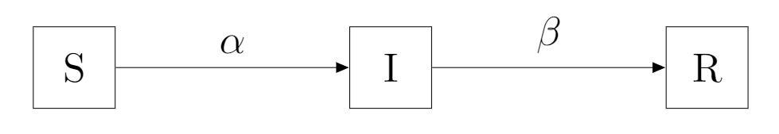

```r
## Loading deSolve package
library(deSolve)

## Creating an SIR function
sir <- function(time, state, parameters) {

  with(as.list(c(state, parameters)), {

    dS <- -alpha * S * I
    dI <-  alpha * S * I - beta * I
    dR <-                  beta * I

    return(list(c(dS, dI, dR)))
  })
}

### Set parameters

## The infection parameter: alpha and the recovery parameter: beta
parameters <- c(alpha = 0.2, beta = 0.03)

## Proportion in each compartment: Susceptible 0.99, Infected 0.01, Recovered 0
init       <- c(S = 1-1e-2, I = 1e-2, R = 0.0)
```

## 1.2 Task 2

Simulate the model until $t=100$ and plot the curves of $S(t)$, $I(t)$ and $R(t)$.

```r
## Time frame
require(tidyr)
t <- 100
times      <- seq(0, t, by = 1)

## Solve using ode (General Solver for Ordinary Differential Equations)
out <- ode(y = init, times = times, func = sir, parms = parameters)
## change to data frame
out <- as.data.frame(out)
## Delete time variable
out$time <- NULL
## Show data
out%>%head()
```

|  | S | I | R |
| --- | --- | --- | --- |
| 1 | 0.9900000 | 0.01000000 | 0.0000000000 |
| 2 | 0.9878460 | 0.01182727 | 0.0003267206 |
| 3 | 0.9853049 | 0.01398200 | 0.0007130763 |
| 4 | 0.9823110 | 0.01651948 | 0.0011695705 |
| 5 | 0.9787860 | 0.01950517 | 0.0017088117 |
| 6 | 0.9746419 | 0.02301279 | 0.0023452602 |

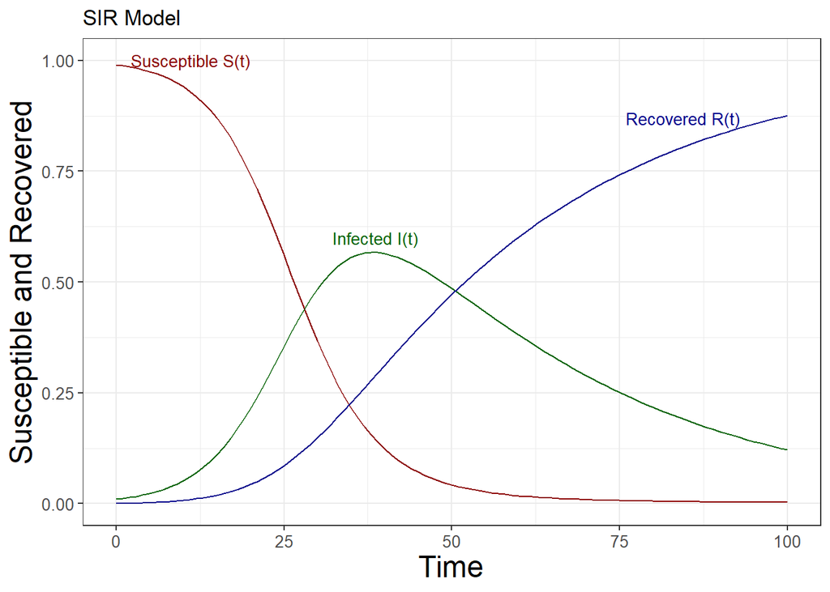

```r
require(ggplot2)
require(tidyr)

out$times <- times

out%>%
  ggplot()+
  geom_line(aes(x=times,y=S),color="darkred")+
  geom_line(aes(x=times,y=I),color="darkgreen")+
  geom_line(aes(x=times,y=R),color="darkblue")+
  annotate('text', 20, 1, label="Susceptible S(t)", hjust=1, size=3.5,color="darkred")+
  annotate('text', 45, 0.6, label="Infected I(t)", hjust=1, size=3.5,color="darkgreen")+
  annotate('text', 93, .87, label="Recovered R(t)", hjust=1, size=3.5,color="darkblue")+
    theme_bw()+
  theme(axis.text.x = element_text(size=10,angle=0,hjust = 0.5),
        axis.text.y = element_text(size=12),
        axis.title = element_text(size=18),
        axis.text.y.left = element_text(size=10),
        strip.text =  element_text(size=12))+
  labs(x="Time", color="",title="SIR Model",
       y= "Susceptible and Recovered")
```

## 1.3 Task 3

How would you model social distancing?

To include a social distancing parameter I would use the following model:

$$\begin{align}
\frac{dS}{dt} &= - \alpha' S I \notag \\
\notag \\
\frac{dI}{dt} &= \alpha' S I - \beta I \notag \\
\notag \\
\frac{dR}{dt} &= \beta I \notag
\end{align}$$

where $\alpha' = \alpha\gamma.$ The $\gamma$ parameter is one minus the proportion of people practicing social distancing ($P_d$), $\gamma = 1-P_d$.

To see this consider the following special cases:

- If $P_d$ is zero, there is no social distancing and $\alpha' = \alpha$;
- If $P_d$ is $0.5$, then the transmission rate $\alpha'$ is half that of the original;
- If $P_d$ is one, there is no social contact and therefore no transmission.

## 1.4 Task 4

How would you model reinfections?

To model reinfections I would use the following model:

$$\begin{align}
\frac{dS}{dt} &= - \alpha' S I + \xi R \notag \\
\notag \\
\frac{dI}{dt} &= \alpha' S I - \beta I \notag \\
\notag \\
\frac{dR}{dt} &= \beta I - \xi R \notag
\end{align}$$

That means that the SIR model becomes an SIRS (Susceptible-Infectious-Recovered-Susceptible) model, where recovery does nor confer lifelong immunity, and individuals may become susceptible again.

The SIRS model

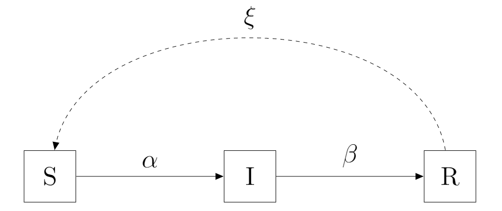

# 2 Genetics

Generell Information

This exercise requires the data set *SNP.RData*, containing 20,000 samples and 4 columns. The column description is as follows:

| Variable | Description | Coding |
| --- | --- | --- |
| id | Sample ID | NA |
| trait | phenotype | continuous |
| sex | sex | 1 = male; 2 = female |
| SNP | genotype | 0 = AA; 1 = AB; 2 = BB |

The variable *SNP* contains data for biallelic SNP with alleles *A* and *B*.

```r
require(ggplot2)
require(tidyr)

load("G:/My Drive/MultiOmic/JobApplicationExercises-main/JobApplicationExercises-main/ExerciseGenetics/SNP.RData")

myDat%>%head()
```

|  | id | trait | sex | SNP |
| --- | --- | --- | --- | --- |
| 1 | 1 | 70.34050 | 2 | 2 |
| 2 | 2 | 61.20060 | 2 | 1 |
| 3 | 3 | 61.82518 | 2 | 1 |
| 4 | 4 | 64.42072 | 2 | 2 |
| 5 | 5 | 70.50646 | 2 | 2 |
| 6 | 6 | 60.21969 | 2 | 2 |

## 2.1 Task 1: Allele frequencies (AF)

Determine the allele frequencies of the given SNP (rounded to three decimal places). How is the result to be interpreted?

```r
myDat$SNP%>%table
```

```
## .
##    0    1    2
## 6351 7550 6099
```

```r
myDat$SNP%>%table/dim(myDat)[1]
```

```
## .
##       0       1       2
## 0.31755 0.37750 0.30495
```

The Hardy-Weinberg law can be used under some circumstances to calculate genotype frequencies from allele frequences. Let A and B be two alleles at the same locus,

- p is the frequency of allele A 0 =< p =< 1
- q is the frequency of allele B 0 =< q =< 1 and p + q = 1
- The frequencies of alleles $F(A)$ be called $p$, and $q$ with $0 =< [p,q] =< 1$ and $p+q = 1$

| Génotypes | AA | AB | BB |  |
| --- | --- | --- | --- | --- |
| Number of subjects | DN | HN | RN | (total number N) |
| Frequencies F(G) | D | H | R | with (D+H+R) = 1 |

| Génotypes | AA | AB | BB |  |
| --- | --- | --- | --- | --- |
| Number of subjects | 6351 | 7550 | 6099 | N = 20000 |
| Frequencies F(G) | 0.318 | 0.377 | 0.305 | with (D+H+R) = 1 |

allele frequencies $F(A)$:

- D = 0.31755
- H = 0.37750
- R = 0.30495
- A: $p=D + H/2$
- B: $q = R + H/2$
- with $p+q=1$

```r
D = 0.31755
H = 0.37750
R = 0.30495


N = 20000

p = D + H/2

q = R + H/2
```

The frequency of allele A and B are $p=$ 0.506 and $q=$ 0.494, and $p+q=$ 1.

**Some implications using The Hardy-Weinberg law:**

The distribution of allele frequencies is the same in men and women, i.e.: hommes $(p,q)$ femmes $(p,q)$

if they procreate : $(p + q)^2 = p^2 + 2pq + q^2 = 1$ , where:

- $p^2 = 0.256$ = frequency of the AA genotype <– HOMOZYGOTE
- $2pq = 0.5$ = frequency of the AB genotype <– HETEROZYGOTE
- $q^2 = 0.244$ = frequency of the BB genotype <– HOMOZYGOTE

these frequencies remain constant in successive generations.

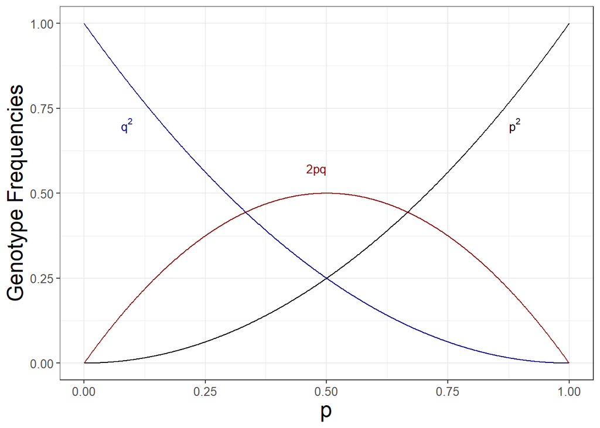

```r
require(ggplot2)
require(tidyr)

p1 = seq(0,1,length=1000)
q1 = 1-p1

fig.dat <- data.frame(
freq=p1,
p2 = p1^2,
q2 = q1^2,
tpq = 2*p1*q1)

fig.dat%>%
  ggplot()+
  geom_line(aes(x=freq,y=p2))+
  geom_line(aes(x=freq,y=q2),color="darkblue")+
  geom_line(aes(x=freq,y=tpq),color="darkred")+
  annotate('text', 0.9, 0.7, label=paste("p^2"), parse=TRUE, hjust=1, size=3.5)+
  annotate('text', 0.1, 0.7, label=paste("q^2"), parse=TRUE, hjust=1, size=3.5,color="darkblue")+
  annotate('text', 0.5, 0.57, label=paste("2*p*q"), parse=TRUE, hjust=1, size=3.5,color="darkred")+
    theme_bw()+
  theme(axis.text.x = element_text(size=10,angle=0,hjust = 0.5),
        axis.text.y = element_text(size=12),
        axis.title = element_text(size=18),
        axis.text.y.left = element_text(size=10),
        strip.text =  element_text(size=12))+
  labs(x="p",
       y= "Genotype Frequencies")
```

- The highest frequency of heterozygotes: The heterozygote (frequency of the AB genotype) achieves its maximum value $2pq = 0.5$.
- Both homozygote configurations have roughly the same frequencies. If one of them is dominant, we can expect that phenotype in about three out of four persons. For instance if A is dominant $ [A] = p^2 + 2pq = 0.75$.

## 2.2 Task 2: Hardy-Weinberg-Equilibrium (HWE)

Determine the expected genotype counts in HWE (rounded to three decimal places). Test the given SNP for deviation of HWE and state the null hypothesis to be tested. How is the result to be interpreted?

Solution:

The observed counts are

- obs_AA = 6351
- obs_AB = 7550
- obs_BB = 6099
- N = 20000

Predicted proportion of $AA = p^{2} = (0.5063)^{2} = 0.2563397$

Predicted proportion of $AB = 2pq = 2*(0.5063)*(0.4937) = 0.4999206$

Predicted proportion of $BB = q^{2} = (0.4937)^{2}= 0.2437397$

Numbers predicted by Hardy-Weinberg :

- for $AA = (p^2)*N = 0.2563397 * 20000 = 5126.794$
- for $AB = 2*p*q*N = 0.4999206 * 20000 = 9998.412$
- for $BB = (q^2)*N = 0.2437397 * 20000 = 4874.794$
- exp_AA = 5126.794
- exp_AB = 9998.412
- exp_BB = 4874.794

**H0: genotype and allele frequencies will remain in their equilibrium state over the generations**

```r
obs_AA = 6351
obs_AB = 7550
obs_BB = 6099

exp_AA = 5126.794
exp_AB = 9998.412
exp_BB = 4874.794


obs <- c(obs_AA,obs_AB,obs_BB)
exp <- c(exp_AA,exp_AB,exp_BB)

chi_statistic = sum(((obs-exp)^2)/exp)

chi_statistic
```

```
## [1] 1199.325
```

```r
#number of degrees of freedom is 2

qchisq(0.95,2)
```

```
## [1] 5.991465
```

```r
5.991465
```

```
## [1] 5.991465
```

**Since the test statistic is large according to that chi-squared distribution, then one rejects the null hypothesis of genotype and allele frequencies will remain in their equilibrium state over the generations.**

- Test in R

```r
# Test

x <- c(AA = obs_AA,AB=obs_AB,BB=obs_BB)
N = sum(x)


library("HardyWeinberg")

HW.test <- HWChisq(x, verbose = TRUE)
```

```
## Chi-square test with continuity correction for Hardy-Weinberg equilibrium (autosomal)
## Chi2 =  1198.591 DF =  1 p-value =  1.234711e-262 D =  -1224.206 f =  0.2448801
```

This shows that the chi-square statistic has value 1198.591, and that the corresponding p value for the test is 1.234711e-262. Taking a significance level of $\alpha = 0.05$. **We reject HWE, meaning that there likely was a disturbance in the equilibrium. It can be caused by a number of factors such as mutations, nonrandom mating or others.**

Note that the HWChisq applies the Yates’ continuity correction. This is not recommended for low minor allele frequencies.

## 2.3 Task 3: Phenotype asssociations

Determine if the SNP is associated with the phenotype and test if this effect is additive, dominant or recessive (state the null hypotheses).

Solution

Quantitative traits are generally analyzed using generalized linear model (GLM) approaches, most commonly the Analysis of Variance (ANOVA), which is similar to linear regression with a categorical predictor variable, in this case genotype classes. The null hypothesis of an ANOVA using a single SNP is that there is no difference between the trait means of any genotype group. The assumptions of GLM and ANOVA are 1) the trait is normally distributed; 2) the trait variance within each group is the same (the groups are homoskedastic); 3) the groups are independent.

- **SNP association analysis**

We are interested in finding those SNPs associated with phenotypes values (trait) that is a continuous quantitative variable. The association analysis for all genetic models is performed by the function association from *SNPassoc* that regresses **trait** on the variable **SNP** from sataset myDat that already contains the SNP variables of class snp.

In this case the association function automatically selects **the error distribution of the regression analysis (either Gaussian)**. In r,

```r
library(SNPassoc)
require(dplyr)

myDat%>%str
```

```
## 'data.frame':    20000 obs. of  4 variables:
##  $ id   : int  1 2 3 4 5 6 7 8 9 10 ...
##  $ trait: num  70.3 61.2 61.8 64.4 70.5 ...
##  $ sex  : int  2 2 2 2 2 2 1 2 2 1 ...
##  $ SNP  : int  2 1 1 2 2 2 1 1 1 1 ...
```

```r
# 0 = AA; 1 = AB; 2 = BB

new <- as.factor(myDat$SNP)

levels(new) <- c("A/A","A/B","B/B")

myDat$coded_snp= new

fit_1 <- association(trait ~ snp(coded_snp), myDat,model = c("dominant","log-additive","recessive"))

fit_1
```

```
##
## SNP: coded_snp  adjusted by:
##                  n    me      se   dif lower upper p-value    AIC
## Dominant
## A/A           6351 55.86 0.07242 0.000                   0 135606
## A/B-B/B      13649 62.54 0.06631 6.682 6.468 6.896
## Recessive
## A/A-A/B      13901 58.14 0.06134 0.000                   0 134736
## B/B           6099 65.62 0.08356 7.483 7.272 7.695
## log-Additive
## 0,1,2                            4.875 4.756 4.995       0 133514
```

This effect is log-additive because it has the lowest AIC value. The IC95% is given by (4.756, 4.995) which does not contain 1.

## 2.4 Task 4: Interaction

Test for a SNP-sex interaction using the genetic model determined in task 3. Visualize the result. How is the result to be interpreted?

```r
fit_2 <- association(trait ~ snp(coded_snp)*as.factor(sex), myDat,model = c("log-additive"))

fit_2
```

```
##
##       SNP: coded_snp  adjusted by:
##  Interaction
## ---------------------
##              1             dif  lower   upper          2            dif  lower
## A/A 5752 54.93 0.06602  0.0000     NA      NA  599 64.81 0.19960  9.887  9.467
## A/B 3770 54.07 0.07970 -0.8607 -1.066 -0.6559 3780 66.03 0.08137 11.099 10.895
## B/B  618 53.23 0.21329 -1.6995 -2.113 -1.2857 5481 67.02 0.06746 12.091 11.907
##     upper
## A/A 10.31
## A/B 11.30
## B/B 12.28
##
## p interaction: < 2.22e-16
##
##  as.factor(sex) within coded_snp
## ---------------------
## A/A
##      n    me      se   dif lower upper
## 1 5752 54.93 0.06602 0.000    NA    NA
## 2  599 64.81 0.19960 9.887 9.467 10.31
##
## A/B
##      n    me      se   dif lower upper
## 1 3770 54.07 0.07970  0.00    NA    NA
## 2 3780 66.03 0.08137 11.96 11.73 12.18
##
## B/B
##      n    me      se   dif lower upper
## 1  618 53.23 0.21329  0.00    NA    NA
## 2 5481 67.02 0.06746 13.79 13.38 14.21
##
## p trend: < 2.22e-16
##
##  coded_snp within as.factor(sex)
## ---------------------
## 1
##        n    me      se     dif  lower   upper
## A/A 5752 54.93 0.06602  0.0000     NA      NA
## A/B 3770 54.07 0.07970 -0.8607 -1.066 -0.6559
## B/B  618 53.23 0.21329 -1.6995 -2.113 -1.2857
##
## 2
##        n    me      se   dif  lower upper
## A/A  599 64.81 0.19960 0.000     NA    NA
## A/B 3780 66.03 0.08137 1.213 0.7828 1.643
## B/B 5481 67.02 0.06746 2.205 1.7840 2.625
##
## p trend: < 2.22e-16
```

The interaction effect is significant which means there are differences between the genders in these phenotypes.

# 3 Personal research

## 3.1 Ação Covid Group

- [Vacination in Brazil SIR Model to Covid19](https://acaocovid19.org/publicacoes/quao-lenta-a-vacinacao-no-brasil)
- [Update 1](https://acaocovid19.org/publicacoes/atualizacao-sob-que-condicoes-a-vacina-conteria-a-pandemia-no-brasil)
- [Update 2](https://acaocovid19.org/publicacoes/atualizacao-a-vacina-conteria-a-pandemia-no-brasil)
- Geohazards and Disaster Risk Reduction: Multidisciplinary and Integrated Approaches: The Covid-19 Protection Index (CPI) as a way to identify vulnerabilities and disparities across Brazilian territories.

## 3.2 Genomic Prediction

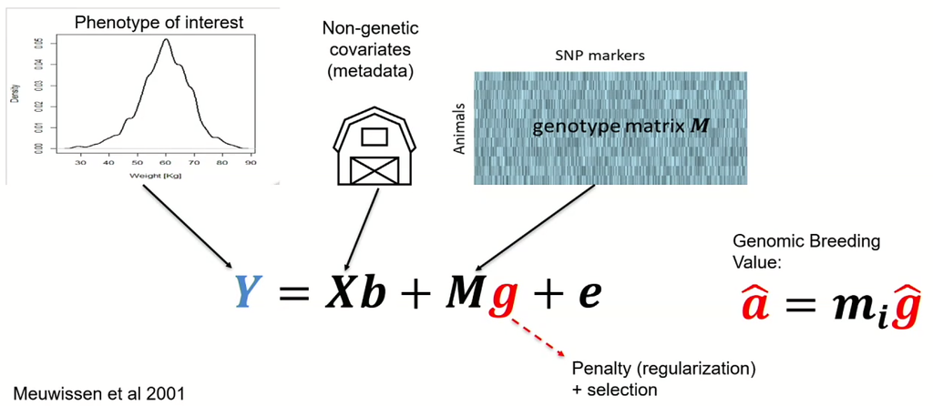